# Udacity Intro to Descriptive Statistics Final Project

# *Questions for Investigation*

For the experiment, I have a standard deck of 52 playing cards divided into four suits (spades (♠), hearts (♥), diamonds (♦), and clubs (♣)), with each suit containing thirteen cards (Ace, the numbers 2 through 10, and the three face cards: Jack, Queen, and King).

For the first part of the experiment, I took 10,000 draws of a single card from the deck, and assigned each card a specified value

- Ace takes a value of 1
- Numbered cards take the value printed on the card
- Jack, Queen, and King each take a value of 10.

Then, we plot a histogram depicting the relative frequencies of the card values, with added lines for the median and mean.

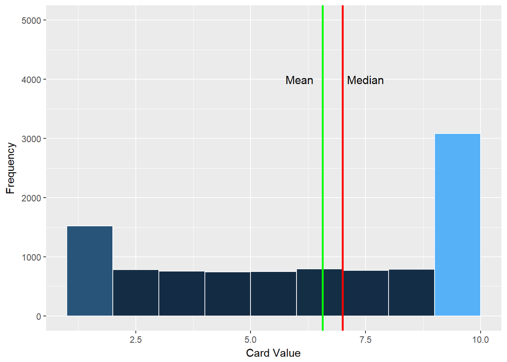

Now, I’ll get samples for a new distribution by drawing three cards from the deck (*without* replacement) and then summing up the three cards’ values into a single value. I then replace the drawn cards back into the deck and repeat this procedure 10,000 times, and then take a look at the distribution of the card sums.

Now I must create a histogram of the sampled card sums.

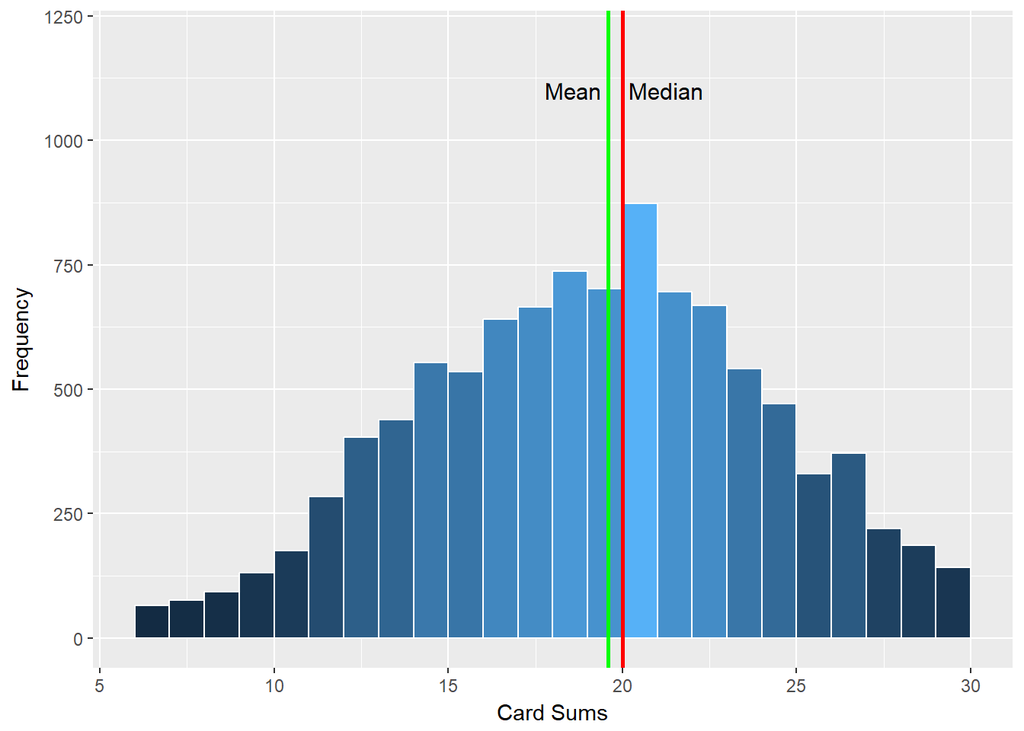

I can see here that my distribution is now very normal-looking. But the mean is slightly pulled to the left of the median, showing that it is *slightly* left skewed, but looking at the histogram, it’s safe to call this a normal distribution.

Compared to our original distribution, this change to a more-normal distribution can be attributed to increasing the sample size from 1 to 3, because a larger sample size creates a larger Z-score for a sample mean, which in turn decreases the proportion of sample means that vary from the sample mean.

We know that 90% of our data values in this distribution are those values with a chance of being selected that is between 5% and 95%, which on a Z-table come out to be Z-score values between **-1.645** and **1.645**.

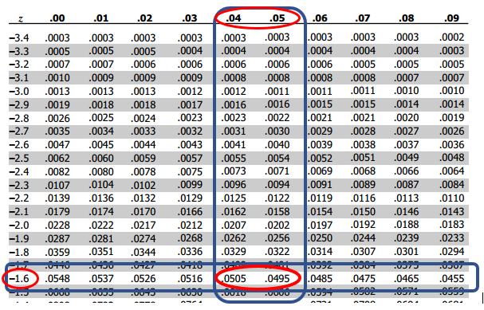

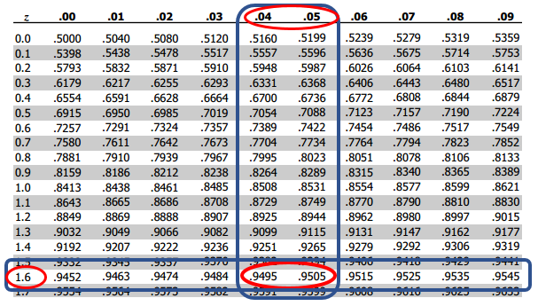

So, if the Z-score is equal to the difference between an observation and the mean divided by the standard deviation, to get those observations between which 90% of our data values fall, we need to multiply each of our Z-score values by the standard deviation and then add the mean.

And if we do that, we’d have **(-1.645 x 4.98) + 19.59** as our lower value, and **(1.645 x 4.98) + 19.59** as our upper value. These formulas give us an lower boundary of

```
## [1] 11.3938
```

and an upper boundary of

```
## [1] 27.786
```

So, 90% of sample sum values fall between **11.3938** and **27.7860**.

To find the approximate probability I would a draw value of at least 20 from this distribution, I would need to find the Z-score for a value of 20 in this distribution, then find the proportion value in the Z-table corresponding to that Z-score, and then subtract this proportion value from 1.

```
## [1] 0.08230925
```

Then I look at the Z-table for this score of **0.08** and retrieve that proportion.

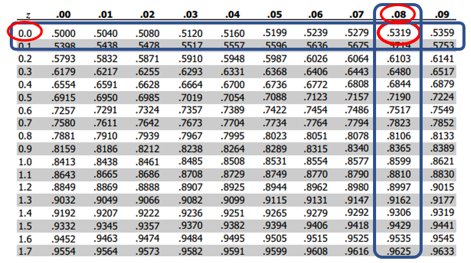

So we’ve got a proportion of **0.5319**, which I subtract from 1 to get the approximate probability I would a draw value of at least 20. So this would be **1 - 0.5319 = 0.4681**, so I have a 46.81% chance of drawing a value of at least 20 from my distribution of sample means.